# Executive Summary

A Supervised Regression Analysis of Monthly Earnings Using the Malawi Longitudinal Study of Families and Health  
Final Project  
Data Science 2 with R (STAT 301-2)

Author

Sarah Norman

Published

March 19, 2025

**Github Repo Link**

[Sarah’s Repo Link (sarahdnor)](https://github.com/stat301-2-2025-winter/final-project-2-sarahdnor.git)

# Prediction Problem

This is a supervised predictive regression problem aimed at predicting the future monthly earnings of women in Malawi three years ahead, using a variety of predictor variables such as education, demographic characteristics, and family life. The data used for predictive modeling in this report is from the Malawi Longitudinal Study of Families and Health (MLSFH) (ICPSR 20840) which was requested and downloaded from Data Sharing for Demographic Research (DSDR), a Population Health Data Archive[^1]. The goal of producing these predictive models on earnings is to observe and explore which subsets of variables yield the most accurate predictions, display predictive importance, and provide insights for further inferential research on which variables may be the most important factors in predicting earnings.

<sup>1</sup> Behrman, J. R., Chimbiri, A. M., Chimwaza, A., Kohler, H.-P., & Watkins, S. C. (2008, May 21). Malawi Longitudinal Study of families and Health (MLSFH).`https://www.icpsr.umich.edu/web/DSDR/studies/20840`

# Results

**RMSE results for all model types and recipes**

Table 1: Avarage RMSE Across All Model Types and Recipes

| wflow_id | mean | std_err |
| --- | --- | --- |
| rf_combined | 1.196 | 0.007 |
| bt_demo_fam | 1.197 | 0.008 |
| rf_edu_demo | 1.198 | 0.007 |
| rf_demo_fam | 1.198 | 0.008 |
| bt_combined | 1.198 | 0.007 |
| en_demo | 1.200 | 0.008 |
| en_demo_fam | 1.200 | 0.007 |
| en_edu_demo | 1.200 | 0.007 |
| en_combined | 1.201 | 0.007 |
| bt_demo | 1.201 | 0.007 |
| rf_demo | 1.201 | 0.008 |
| bt_edu_demo | 1.202 | 0.006 |
| rf_edu | 1.208 | 0.007 |
| en_edu | 1.208 | 0.007 |
| rf_edu_fam | 1.208 | 0.007 |
| bt_edu | 1.209 | 0.007 |
| lm_demo | 1.210 | 0.008 |
| lm_edu | 1.210 | 0.007 |
| bt_edu_fam | 1.211 | 0.008 |
| en_edu_fam | 1.212 | 0.007 |
| lm_demo_fam | 1.216 | 0.008 |
| lm_edu_demo | 1.217 | 0.007 |
| lm_edu_fam | 1.219 | 0.007 |
| lm_combined | 1.223 | 0.007 |
| rf_fam | 1.225 | 0.007 |
| bt_fam | 1.226 | 0.007 |
| en_fam | 1.227 | 0.008 |
| lm_fam | 1.237 | 0.007 |
| knn_combined | 1.508 | 0.017 |
| knn_demo_fam | 1.542 | 0.020 |
| knn_edu_demo | 1.555 | 0.020 |
| knn_demo | 1.591 | 0.017 |
| knn_edu_fam | 1.672 | 0.019 |
| knn_fam | 1.906 | 0.054 |
| knn_edu | 2.154 | 0.022 |

## Predictive importance

There are some patterns in the data, as previously mentioned, but they lack significant stability across models. Performance differences, as measured by RMSE, are relatively small, indicating that recipe composition may not lead to substantial improvements in prediction. Therefore, it is challenging to conclude that variations in recipe composition strongly determine predictive importance, aside from the observation that demographic variables generally enhance predictive performance, while family and household-related predictors may not lead to the most accurate predictions.

## Performance of final model

The random forest model was chosen as the final/best model as it had the lowest average RMSE value and relavtivley low standard error which can be seen in Table 1.

Table 2: Final Model Performance Metrics (Converted to Original Scale)

| metric | estimate |
| --- | --- |
| rmse | 13.589 |
| mae | 6.733 |
| rsq | 0.078 |

Table 2 shows that the model’s typical error is ~13.5 kwacha from the actual value as shown by the RMSE. The mean absolute error of the model is ~7 kwacha. Lastly, the R-squared value of 0.078 indicates that the model only captures 7.8% of the variance in women’s monthly earnings.

Although the errors of this model are relatively small (which we can note by comparing them to the mean monthly earnings calculated where average monthly earnings is ~192), the model actually performs pretty poorly. The R-squared value is very low, meaning the model does not do a good job at explaining variance, indicating that the vast majority of the patterns in monthly earnings cannot be explained by the model.

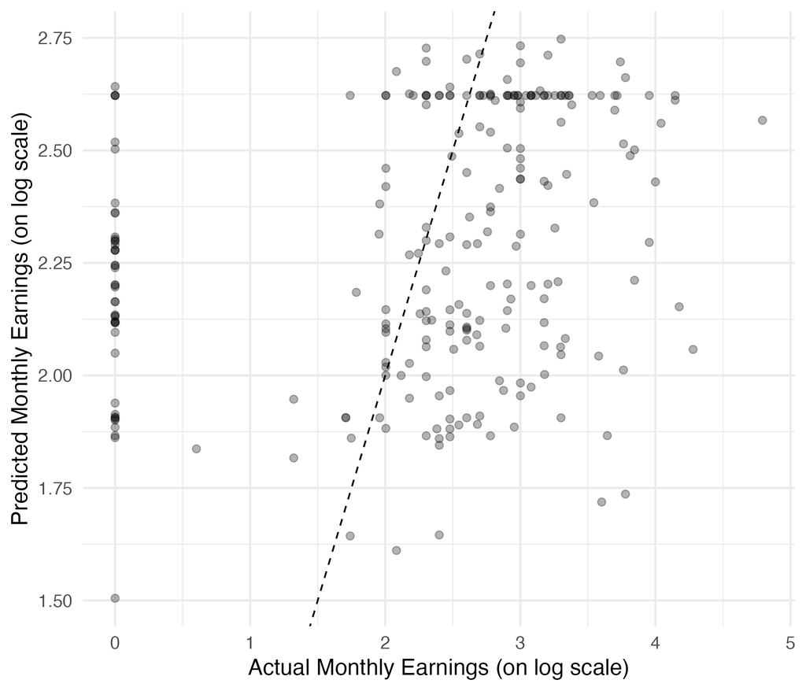

Figure 1: Comparison of Final Model’s Monthly Earnings Predictions vs. Actual Monthly Earnings

# Conclusions

Although analysis aimed to compare systematic differences in performance between recipes that used specific predictor variable subsets alongside model types, variation in recipes did not lead to strong conclusions about the predictive importance of certain variables, as no distinct patterns emerged from the data. While further investigation might be valuable to understand why demographic predictor variables appeared to produce the strongest predictive performance in this report, the differences between models remain relatively small across model types.

Future research may also include examining other subsets of predictor variables, such as social or behavioral factors, to further refine predictive modeling and better understand the predictive importance of variables in predicting monthly earnings of women in Malawi. However, this would require analyzing different survey results, as these values were not included in this dataset. Additionally, a more robust predictive model incorporating additional demographic predictors could help determine whether these variables lead to a significant increase in model performance. Furthermore, incorporating interaction terms could provide insights into whether combinations of predictor variables produce unique results.

## Use of AI

This analysis utilized AI, specifically ChatGPT-4 and ChatGPT-3, for problem-solving, as well as for spelling and grammar checks. Text was frequently input into ChatGPT to review and correct spelling and grammar. AI was also approached for sugestions on how to improve descriptions and or analysis. On a few occasions, code was also input into ChatGPT for debugging; however, the platform did not prove to be particularly helpful in this regard, producing overly complicated solutions using unfamiliar functions and arguments.

For the executive summary, AI was specifically used in the creation of Table 1 to understand how to use functions for color-coding columns.